# class8 machine learning

# k-means clustering example

Let’s make up some datafor testing the ‘kmeans()’ function

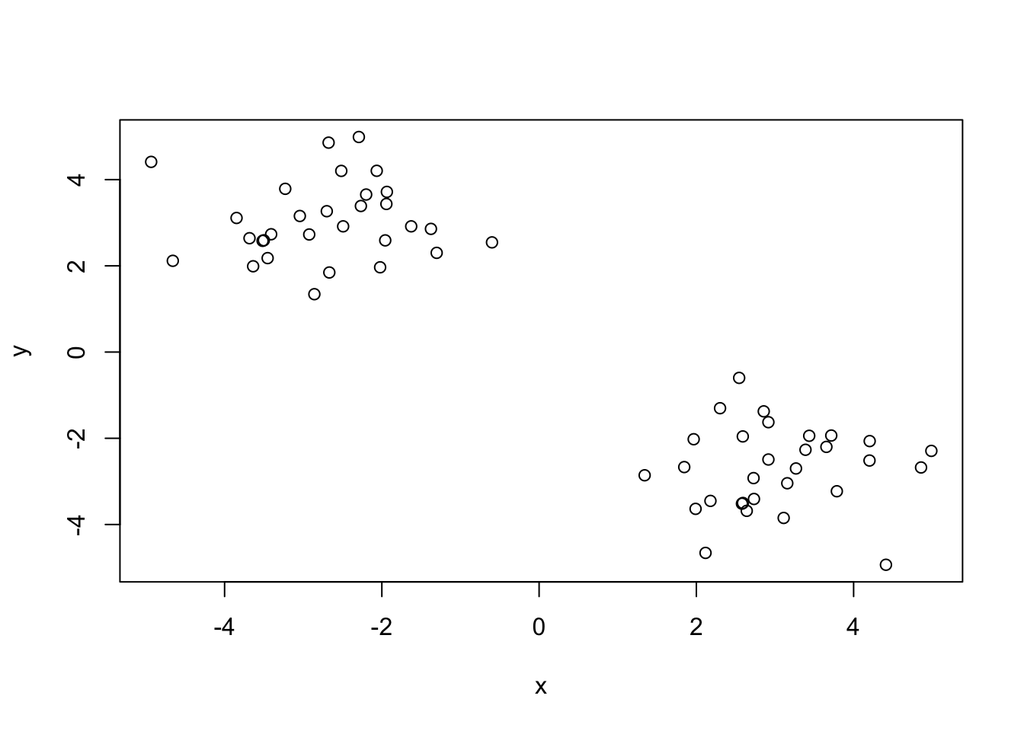

```r
tmp <- c(rnorm(30,-3), rnorm(30,3)) #a vector of points from two random distributions
x <- cbind(x=tmp, y=rev(tmp)) #binding it in a matrix with two columns, one with tmp and one with the reverse of tmp
plot(x)
```

```r
km <- kmeans(x, centers = 2, nstart = 10)
```

```r
km$size
```

```
## [1] 30 30
```

Q. What ‘component’ of your result object details - cluster size?

```r
km$cluster
```

```
##  [1] 2 2 2 2 2 2 2 2 2 2 2 2 2 2 2 2 2 2 2 2 2 2 2 2 2 2 2 2 2 2 1 1 1 1 1
## [36] 1 1 1 1 1 1 1 1 1 1 1 1 1 1 1 1 1 1 1 1 1 1 1 1 1
```

```
  - cluster assignment/membership?
  - cluster center?
```

```r
km$centers
```

```
##           x         y
## 1  3.033886 -2.710941
## 2 -2.710941  3.033886
```

Plot x colored by the kmeans cluster assignment and add cluster centers as blue points

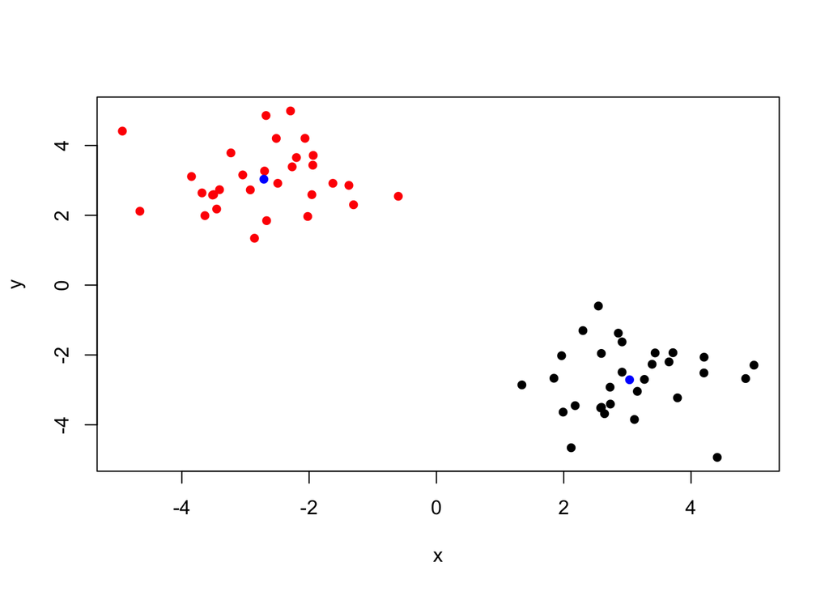

```r
plot(x, col = km$cluster, pch = 16) #plot the data with coloring for each cluster
points(km$centers, col = "blue", pch = 16) #points() adds points on top of the graph
```

# Hierarchical clustering:

First we need to calculate point (dis)similarity as the Euclidean distance between observations

```r
dist_matrix <- dist(x) #calculates all pairwise distances.
dim(dist_matrix) #doesn't work as dist_matrix is not a dataframe.
```

[output not shown]

```r
dmatrix <- as.matrix(dist_matrix)
#View( dmatrix ) #view() works with dataframe. as.matrix() forces it to be a matrix.
dim(x) #60 points
```

```
## [1] 60  2
```

```r
dim( as.matrix(dist_matrix) ) #60x60 pairwise distances
```

```
## [1] 60 60
```

Now let’s use hc()

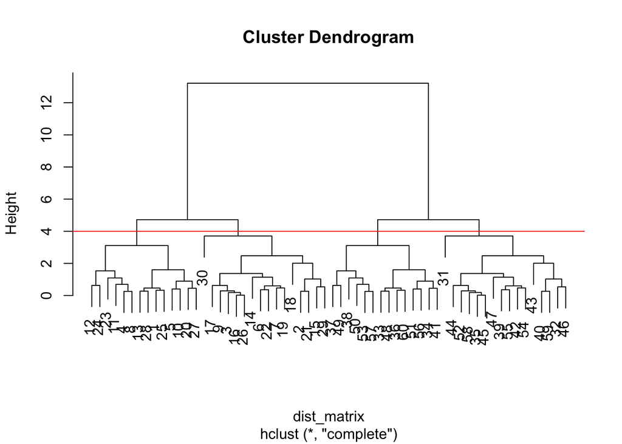

```r
hc <- hclust(dist_matrix) #calculate the hierachical clustering
plot(hc) #plot as a dendogram
abline(h=4, col="red") #add a 'cutoff' line on the dendogram.
```

Cut the tree by height…

```r
groups <- cutree(hc, h=6) #cut by height=4
groups
```

```
##  [1] 1 1 1 1 1 1 1 1 1 1 1 1 1 1 1 1 1 1 1 1 1 1 1 1 1 1 1 1 1 1 2 2 2 2 2
## [36] 2 2 2 2 2 2 2 2 2 2 2 2 2 2 2 2 2 2 2 2 2 2 2 2 2
```

```r
table(groups)
```

```
## groups
##  1  2
## 30 30
```

Plot it

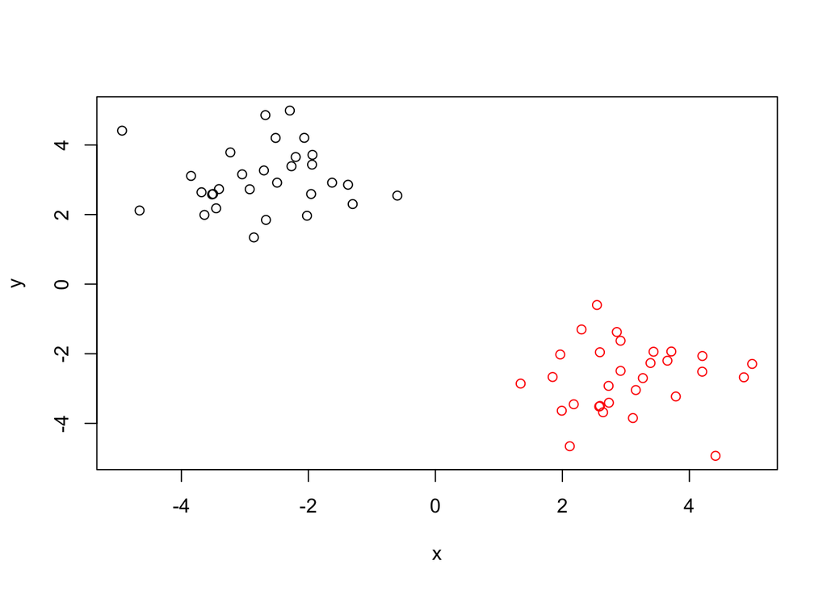

```r
plot(x, col=cutree(hc, h=6))
```

… or by k

```r
kgroups <- cutree(hc, k=4) #cut by k=4
table(kgroups)
```

```
## kgroups
##  1  2  3  4
## 14 16 16 14
```

and plot it

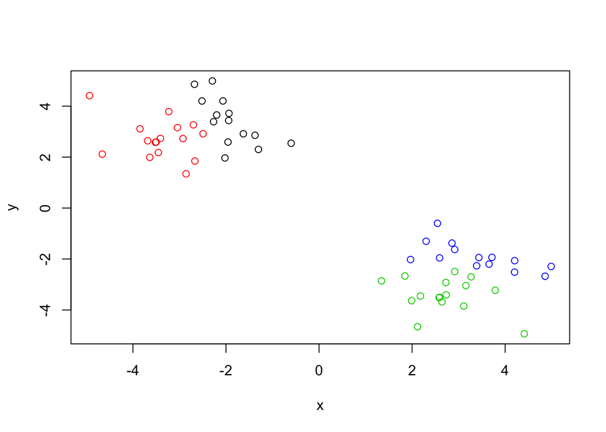

```r
plot(x, col=cutree(hc, k=4))
```

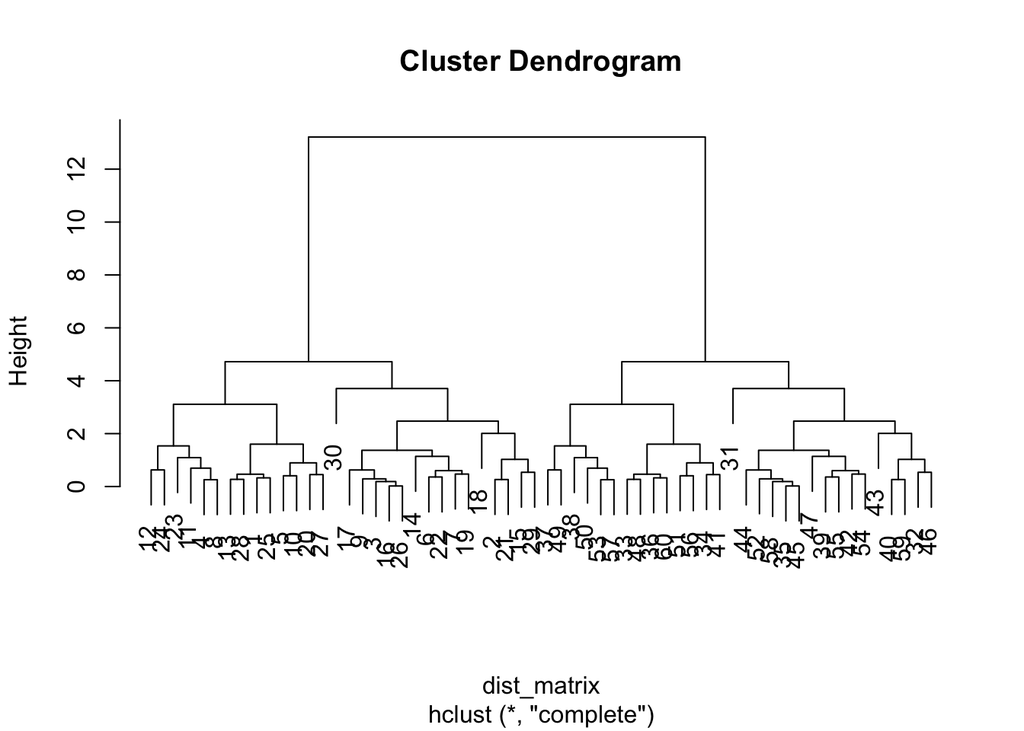

```r
hc.complete <- hclust(dist_matrix, method="complete")
plot(hc.complete)
```

```r
hc.average  <- hclust(dist_matrix, method="average")
hc.single   <- hclust(dist_matrix, method="single")
```

# Exercise

Step 1. Generate some example data for clustering

```r
x <- rbind(
  matrix(rnorm(100, mean=0, sd = 0.3), ncol = 2),   # c1
  matrix(rnorm(100, mean = 1, sd = 0.3), ncol = 2), # c2
  matrix(c(rnorm(50, mean = 1, sd = 0.3),           # c3
           rnorm(50, mean = 0, sd = 0.3)), ncol = 2))
colnames(x) <- c("x", "y")
str(x)
```

```
##  num [1:150, 1:2] 0.0903 0.2622 -0.2283 -0.1959 -0.3121 ...
##  - attr(*, "dimnames")=List of 2
##   ..$ : NULL
##   ..$ : chr [1:2] "x" "y"
```

Step 2. Plot the data without clustering

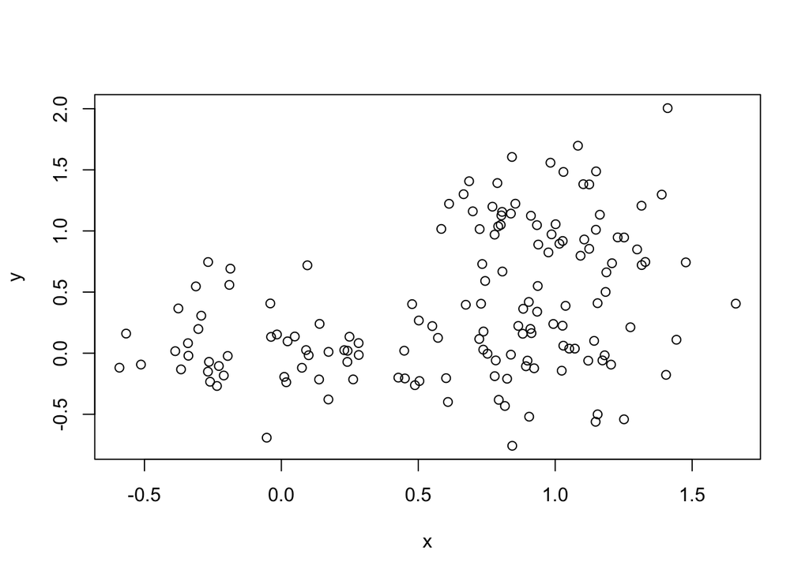

```r
plot(x)
```

Step 3. Generate colors for known clusters (just so we can compare to hclust results)

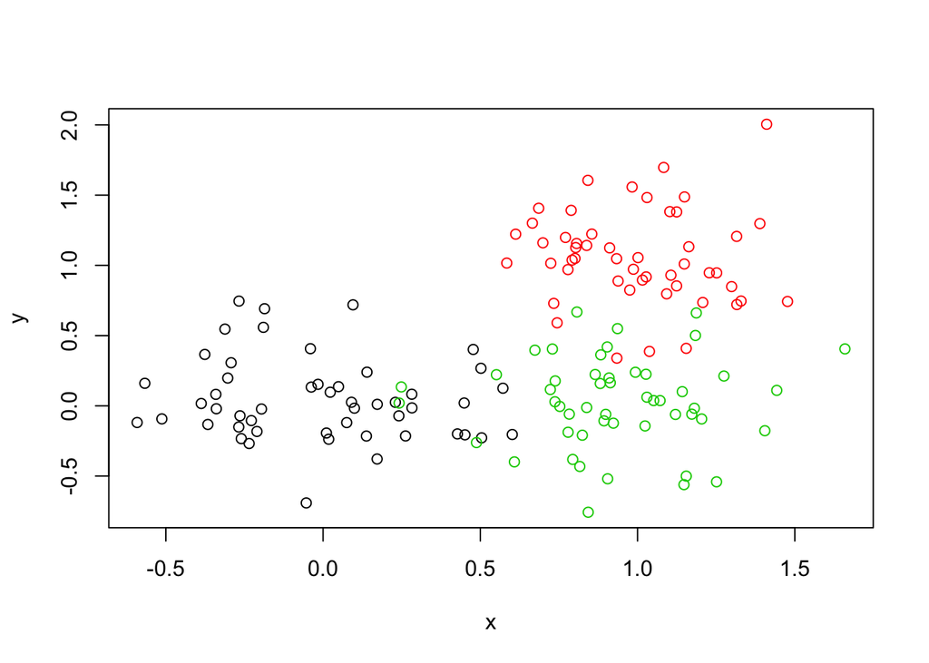

```r
col <- as.factor( rep(c("c1","c2","c3"), each=50) )
plot(x, col=col)
```

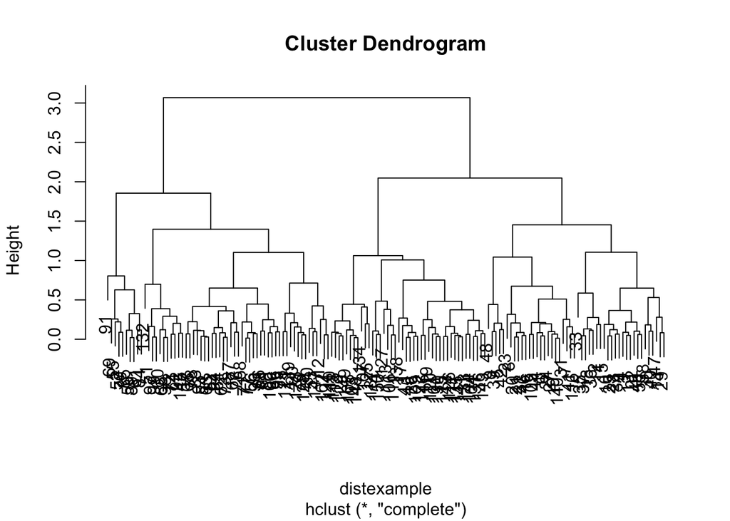

```r
distexample <- dist(x) #calculate distances
clustexample <- hclust(distexample)
plot(clustexample) #plot as a dendogram
```

and then plot the data with different groupings

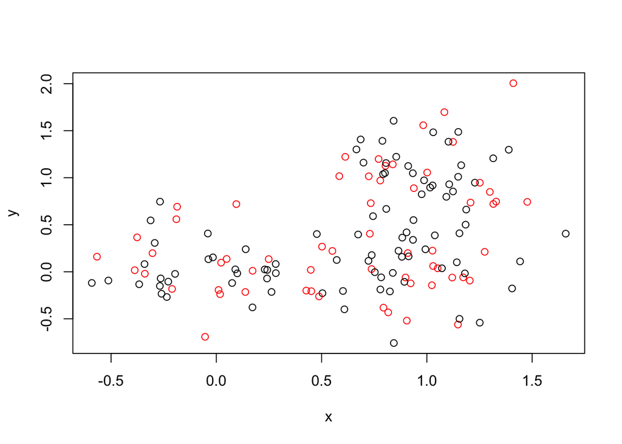

```r
plot(x, col=cutree(hc, k=2))
```

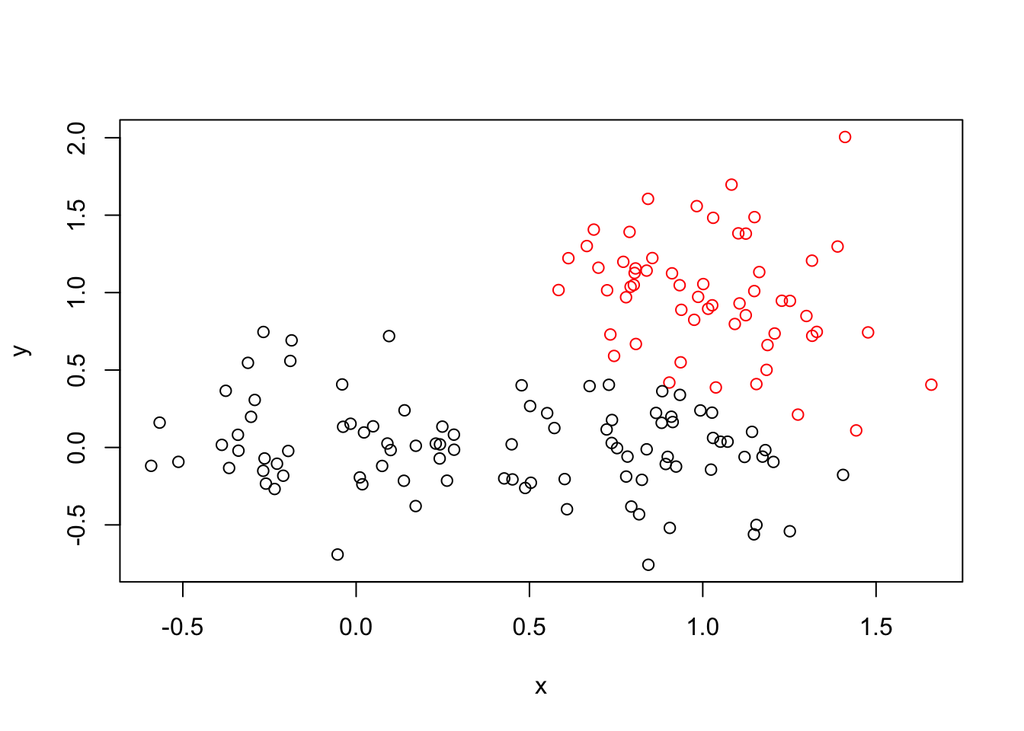

```r
kmexample <- kmeans(x, centers = 2, nstart = 10)
plot(x, col= kmexample$cluster)
```

looks better!